# Between Sample (Beta) Diversity of Microbes

2024-04-24

# Goals

1. Load in phyloseq data with rooted tree.
2. Evaluate sequencing depth and remove sample.
3. Normalize the read counts between samples.
4. Calculate community dissimilarities. Numbers between 0 and 1. If 0, completely similar versus if they are 1, then they’re completely dissimilar.
   1. **Sorensen**: Shared Species as a binary value: Abundance-unweighted
   2. **Bray-Curtis**: Shared Abundant species: Abundance-weighted
   3. **(Abundance-)Weighted UNIFRAC**: Consider Abundant Species and where they fall on the tree
5. Visualize the community data with two unconstrained Ordinations:
   1. **PCoA**: Linear Method. Eigenvalue = how much variation is explained by each axis. Choose to view axis 1, 2, 3, etc. and plot them together.
   2. **NMDS**: Non-linear. Smush multiple Dimensions into 2 or 3 axes. Need to report Stress value (ideally <0.15).
6. Run statistics with PERMANOVA and betadispR.

# Setup

## Set the seed

```r
# Any number can be chosen
set.seed(238428)
```

## Load Libraries

```r
#install.packages("vegan")
pacman::p_load(tidyverse, devtools, phyloseq, patchwork, vegan,
               install = FALSE)
```

## Load Data

```r
# Load in rooted phylogenetic tree!
load("data/03_Phylogenetic_Tree/phytree_preprocessed_physeq.RData")
midroot_physeq
```

```
## phyloseq-class experiment-level object
## otu_table()   OTU Table:         [ 658 taxa and 10 samples ]
## sample_data() Sample Data:       [ 10 samples by 10 sample variables ]
## tax_table()   Taxonomy Table:    [ 658 taxa by 9 taxonomic ranks ]
## phy_tree()    Phylogenetic Tree: [ 658 tips and 657 internal nodes ]
```

```r
unrooted_physeq_rmNA
```

```
## phyloseq-class experiment-level object
## otu_table()   OTU Table:         [ 658 taxa and 10 samples ]
## sample_data() Sample Data:       [ 10 samples by 10 sample variables ]
## tax_table()   Taxonomy Table:    [ 658 taxa by 9 taxonomic ranks ]
## phy_tree()    Phylogenetic Tree: [ 658 tips and 657 internal nodes ]
```

# Explore Read Counts

## Raw read depth

```r
# Calculate the total number of reads per sample.
raw_TotalSeqs_df  <-
  midroot_physeq %>%
  # calculate the sample read sums
  sample_sums() %>%
  data.frame()
# name the column
colnames(raw_TotalSeqs_df)[1] <- "TotalSeqs"

print(raw_TotalSeqs_df)
```

```
##             TotalSeqs
## ERR11588428       242
## ERR11588429       263
## ERR11588430       112
## ERR11588431      3005
## ERR11588432      5382
## ERR11588433         0
## ERR11588434       214
## ERR11588435       167
## ERR11588436      4990
## ERR11588437     14022
```

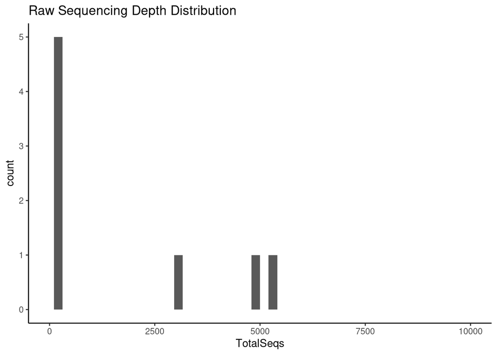

```r
# make histogram of raw reads
raw_TotalSeqs_df %>%
  ggplot(aes(x = TotalSeqs)) +
  geom_histogram(bins = 50) +
  scale_x_continuous(limits = c(0, 10000)) +
  labs(title = "Raw Sequencing Depth Distribution") +
  theme_classic()
```